# Risk Factor Analysis

## Outcome Variable

**Outcome Variable:** ever_wasted

## Predictor Variables

**Intervention Variable:** feducyrs

**Adjustment Set:**

- arm
- W_mage
- meducyrs
- hhwealth_quart
- W_mhtcm
- W_gagebrth
- W_birthwt
- W_birthlen
- single
- delta_W_mage
- delta_meducyrs
- delta_hhwealth_quart
- delta_W_mhtcm
- delta_W_gagebrth
- delta_W_birthwt
- delta_W_birthlen
- delta_single

## Stratifying Variables

The analysis was stratified on these variable(s):

- agecat
- studyid
- country

## Data Summary

| agecat | studyid | country | feducyrs | ever_wasted | n_cell | n |
| --- | --- | --- | --- | --- | --- | --- |
| 0-24 months | ki0047075b-MAL-ED | BANGLADESH | High | 0 | 41 | 147 |
| 0-24 months | ki0047075b-MAL-ED | BANGLADESH | High | 1 | 13 | 147 |
| 0-24 months | ki0047075b-MAL-ED | BANGLADESH | Low | 0 | 23 | 147 |
| 0-24 months | ki0047075b-MAL-ED | BANGLADESH | Low | 1 | 16 | 147 |
| 0-24 months | ki0047075b-MAL-ED | BANGLADESH | Medium | 0 | 36 | 147 |
| 0-24 months | ki0047075b-MAL-ED | BANGLADESH | Medium | 1 | 18 | 147 |
| 0-24 months | ki0047075b-MAL-ED | INDIA | High | 0 | 22 | 147 |
| 0-24 months | ki0047075b-MAL-ED | INDIA | High | 1 | 22 | 147 |
| 0-24 months | ki0047075b-MAL-ED | INDIA | Low | 0 | 28 | 147 |
| 0-24 months | ki0047075b-MAL-ED | INDIA | Low | 1 | 31 | 147 |
| 0-24 months | ki0047075b-MAL-ED | INDIA | Medium | 0 | 27 | 147 |
| 0-24 months | ki0047075b-MAL-ED | INDIA | Medium | 1 | 17 | 147 |
| 0-24 months | ki0047075b-MAL-ED | NEPAL | High | 0 | 32 | 98 |
| 0-24 months | ki0047075b-MAL-ED | NEPAL | High | 1 | 10 | 98 |
| 0-24 months | ki0047075b-MAL-ED | NEPAL | Low | 0 | 18 | 98 |
| 0-24 months | ki0047075b-MAL-ED | NEPAL | Low | 1 | 10 | 98 |
| 0-24 months | ki0047075b-MAL-ED | NEPAL | Medium | 0 | 19 | 98 |
| 0-24 months | ki0047075b-MAL-ED | NEPAL | Medium | 1 | 9 | 98 |
| 0-24 months | ki0047075b-MAL-ED | PERU | High | 0 | 112 | 250 |
| 0-24 months | ki0047075b-MAL-ED | PERU | High | 1 | 8 | 250 |
| 0-24 months | ki0047075b-MAL-ED | PERU | Low | 0 | 65 | 250 |
| 0-24 months | ki0047075b-MAL-ED | PERU | Low | 1 | 4 | 250 |
| 0-24 months | ki0047075b-MAL-ED | PERU | Medium | 0 | 54 | 250 |
| 0-24 months | ki0047075b-MAL-ED | PERU | Medium | 1 | 7 | 250 |
| 0-24 months | ki0047075b-MAL-ED | SOUTH AFRICA | High | 0 | 36 | 110 |
| 0-24 months | ki0047075b-MAL-ED | SOUTH AFRICA | High | 1 | 7 | 110 |
| 0-24 months | ki0047075b-MAL-ED | SOUTH AFRICA | Low | 0 | 30 | 110 |
| 0-24 months | ki0047075b-MAL-ED | SOUTH AFRICA | Low | 1 | 7 | 110 |
| 0-24 months | ki0047075b-MAL-ED | SOUTH AFRICA | Medium | 0 | 23 | 110 |
| 0-24 months | ki0047075b-MAL-ED | SOUTH AFRICA | Medium | 1 | 7 | 110 |

[output cut: 330 more lines]

The following strata were considered:

- agecat: 0-24 months, studyid: ki0047075b-MAL-ED, country: BANGLADESH
- agecat: 0-24 months, studyid: ki0047075b-MAL-ED, country: INDIA
- agecat: 0-24 months, studyid: ki0047075b-MAL-ED, country: NEPAL
- agecat: 0-24 months, studyid: ki0047075b-MAL-ED, country: PERU
- agecat: 0-24 months, studyid: ki0047075b-MAL-ED, country: SOUTH AFRICA
- agecat: 0-24 months, studyid: ki0047075b-MAL-ED, country: TANZANIA, UNITED REPUBLIC OF
- agecat: 0-24 months, studyid: ki1000304b-SAS-CompFeed, country: INDIA
- agecat: 0-24 months, studyid: ki1000304b-SAS-FoodSuppl, country: INDIA
- agecat: 0-24 months, studyid: ki1017093b-PROVIDE, country: BANGLADESH
- agecat: 0-24 months, studyid: ki1017093c-NIH-Crypto, country: BANGLADESH
- agecat: 0-24 months, studyid: ki1066203-TanzaniaChild2, country: TANZANIA, UNITED REPUBLIC OF
- agecat: 0-24 months, studyid: ki1113344-GMS-Nepal, country: NEPAL
- agecat: 0-24 months, studyid: ki1119695-PROBIT, country: BELARUS
- agecat: 0-24 months, studyid: ki1126311-ZVITAMBO, country: ZIMBABWE
- agecat: 0-24 months, studyid: ki1135781-COHORTS, country: GUATEMALA
- agecat: 0-24 months, studyid: ki1135781-COHORTS, country: INDIA
- agecat: 0-24 months, studyid: ki1135781-COHORTS, country: PHILIPPINES
- agecat: 0-24 months, studyid: ki1148112-LCNI-5, country: MALAWI
- agecat: 0-24 months, studyid: kiGH5241-JiVitA-3, country: BANGLADESH
- agecat: 0-24 months, studyid: kiGH5241-JiVitA-4, country: BANGLADESH
- agecat: 0-6 months, studyid: ki0047075b-MAL-ED, country: BANGLADESH
- agecat: 0-6 months, studyid: ki0047075b-MAL-ED, country: INDIA
- agecat: 0-6 months, studyid: ki0047075b-MAL-ED, country: NEPAL
- agecat: 0-6 months, studyid: ki0047075b-MAL-ED, country: PERU
- agecat: 0-6 months, studyid: ki0047075b-MAL-ED, country: SOUTH AFRICA
- agecat: 0-6 months, studyid: ki0047075b-MAL-ED, country: TANZANIA, UNITED REPUBLIC OF
- agecat: 0-6 months, studyid: ki1000304b-SAS-CompFeed, country: INDIA
- agecat: 0-6 months, studyid: ki1000304b-SAS-FoodSuppl, country: INDIA
- agecat: 0-6 months, studyid: ki1017093b-PROVIDE, country: BANGLADESH
- agecat: 0-6 months, studyid: ki1017093c-NIH-Crypto, country: BANGLADESH
- agecat: 0-6 months, studyid: ki1066203-TanzaniaChild2, country: TANZANIA, UNITED REPUBLIC OF
- agecat: 0-6 months, studyid: ki1113344-GMS-Nepal, country: NEPAL
- agecat: 0-6 months, studyid: ki1119695-PROBIT, country: BELARUS
- agecat: 0-6 months, studyid: ki1126311-ZVITAMBO, country: ZIMBABWE
- agecat: 0-6 months, studyid: ki1135781-COHORTS, country: GUATEMALA
- agecat: 0-6 months, studyid: ki1135781-COHORTS, country: INDIA
- agecat: 0-6 months, studyid: ki1135781-COHORTS, country: PHILIPPINES
- agecat: 0-6 months, studyid: ki1148112-LCNI-5, country: MALAWI
- agecat: 0-6 months, studyid: kiGH5241-JiVitA-3, country: BANGLADESH
- agecat: 0-6 months, studyid: kiGH5241-JiVitA-4, country: BANGLADESH
- agecat: 6-24 months, studyid: ki0047075b-MAL-ED, country: BANGLADESH
- agecat: 6-24 months, studyid: ki0047075b-MAL-ED, country: INDIA
- agecat: 6-24 months, studyid: ki0047075b-MAL-ED, country: NEPAL
- agecat: 6-24 months, studyid: ki0047075b-MAL-ED, country: PERU
- agecat: 6-24 months, studyid: ki0047075b-MAL-ED, country: SOUTH AFRICA
- agecat: 6-24 months, studyid: ki0047075b-MAL-ED, country: TANZANIA, UNITED REPUBLIC OF
- agecat: 6-24 months, studyid: ki1000304b-SAS-CompFeed, country: INDIA
- agecat: 6-24 months, studyid: ki1000304b-SAS-FoodSuppl, country: INDIA
- agecat: 6-24 months, studyid: ki1017093b-PROVIDE, country: BANGLADESH
- agecat: 6-24 months, studyid: ki1017093c-NIH-Crypto, country: BANGLADESH
- agecat: 6-24 months, studyid: ki1066203-TanzaniaChild2, country: TANZANIA, UNITED REPUBLIC OF
- agecat: 6-24 months, studyid: ki1113344-GMS-Nepal, country: NEPAL
- agecat: 6-24 months, studyid: ki1119695-PROBIT, country: BELARUS
- agecat: 6-24 months, studyid: ki1126311-ZVITAMBO, country: ZIMBABWE
- agecat: 6-24 months, studyid: ki1135781-COHORTS, country: GUATEMALA
- agecat: 6-24 months, studyid: ki1135781-COHORTS, country: INDIA
- agecat: 6-24 months, studyid: ki1135781-COHORTS, country: PHILIPPINES
- agecat: 6-24 months, studyid: ki1148112-LCNI-5, country: MALAWI
- agecat: 6-24 months, studyid: kiGH5241-JiVitA-3, country: BANGLADESH
- agecat: 6-24 months, studyid: kiGH5241-JiVitA-4, country: BANGLADESH

### Dropped Strata

Some strata were dropped due to rare outcomes:

- agecat: 0-24 months, studyid: ki0047075b-MAL-ED, country: PERU
- agecat: 0-24 months, studyid: ki0047075b-MAL-ED, country: TANZANIA, UNITED REPUBLIC OF
- agecat: 0-6 months, studyid: ki0047075b-MAL-ED, country: NEPAL
- agecat: 0-6 months, studyid: ki0047075b-MAL-ED, country: PERU
- agecat: 0-6 months, studyid: ki0047075b-MAL-ED, country: SOUTH AFRICA
- agecat: 0-6 months, studyid: ki0047075b-MAL-ED, country: TANZANIA, UNITED REPUBLIC OF
- agecat: 0-6 months, studyid: ki1148112-LCNI-5, country: MALAWI
- agecat: 6-24 months, studyid: ki0047075b-MAL-ED, country: NEPAL
- agecat: 6-24 months, studyid: ki0047075b-MAL-ED, country: PERU
- agecat: 6-24 months, studyid: ki0047075b-MAL-ED, country: SOUTH AFRICA
- agecat: 6-24 months, studyid: ki0047075b-MAL-ED, country: TANZANIA, UNITED REPUBLIC OF

## Methods Detail

We’re interested in the causal parameters $E[Y_a]$ for all values of $a \in \mathcal{A}$. These parameters represent the mean outcome if, possibly contrary to fact, we intervened to set all units to have $A=a$. Under the randomization and positivity assumptions, these are identified by the statistical parameters $\psi_a=E_W[E_{Y|A,W}(Y|A=a,W)]$. In addition, we’re interested in the mean of $Y$, $E[Y]$ under no intervention (the observed mean). We will estimate these parameters by using SuperLearner to fit the relevant likelihood factors – $E_{Y|A,W}(Y|A=a,W)$ and $p(A=a|W)$, and then updating our likelihood fit using a joint TMLE.

For unadjusted analyses ($W=\{\}$), initial likelihoods were estimated using Lrnr_glm to estimate the simple $E(Y|A)$ and Lrnr_mean to estimate $p(A)$. For adjusted analyses, a small library containing Lrnr_glmnet, Lrnr_xgboost, and Lrnr_mean was used.

Having estimated these parameters, we will then use the delta method to estimate relative risks and attributable risks relative to a prespecified baseline level of $A$.

# Results Detail

## Results Plots

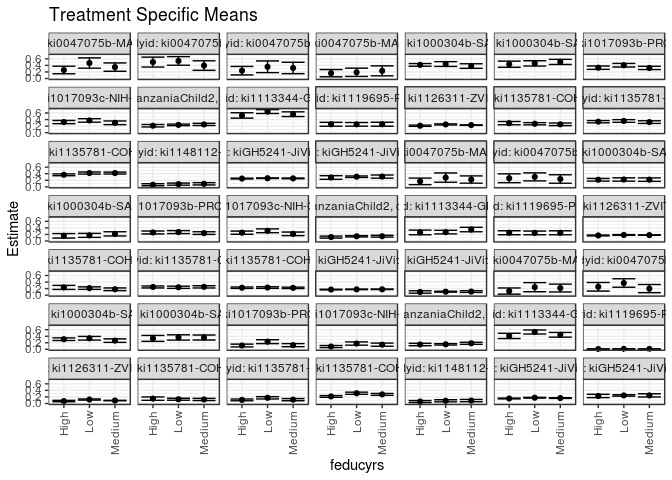

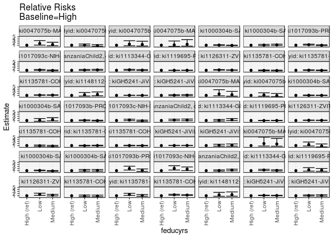

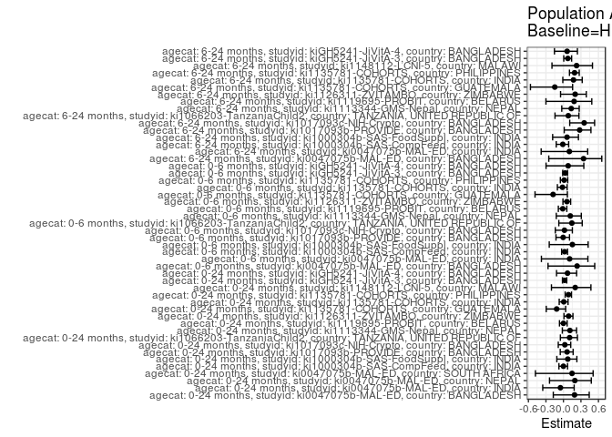

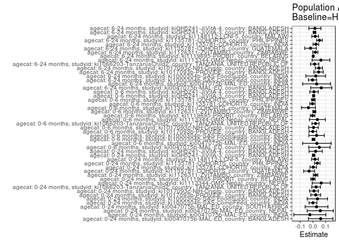

## Results Table

### Parameter: TSM

| agecat | studyid | country | intervention_level | baseline_level | estimate | ci_lower | ci_upper |
| --- | --- | --- | --- | --- | --- | --- | --- |
| 0-24 months | ki0047075b-MAL-ED | BANGLADESH | High | NA | 0.2588308 | 0.1435349 | 0.3741267 |
| 0-24 months | ki0047075b-MAL-ED | BANGLADESH | Low | NA | 0.4723164 | 0.3151578 | 0.6294750 |
| 0-24 months | ki0047075b-MAL-ED | BANGLADESH | Medium | NA | 0.3476247 | 0.2204926 | 0.4747568 |
| 0-24 months | ki0047075b-MAL-ED | INDIA | High | NA | 0.5006817 | 0.3498937 | 0.6514698 |
| 0-24 months | ki0047075b-MAL-ED | INDIA | Low | NA | 0.5356251 | 0.4046454 | 0.6666049 |
| 0-24 months | ki0047075b-MAL-ED | INDIA | Medium | NA | 0.3952439 | 0.2491717 | 0.5413160 |
| 0-24 months | ki0047075b-MAL-ED | NEPAL | High | NA | 0.2380952 | 0.1086231 | 0.3675674 |
| 0-24 months | ki0047075b-MAL-ED | NEPAL | Low | NA | 0.3571429 | 0.1787512 | 0.5355345 |
| 0-24 months | ki0047075b-MAL-ED | NEPAL | Medium | NA | 0.3214286 | 0.1475539 | 0.4953032 |
| 0-24 months | ki0047075b-MAL-ED | SOUTH AFRICA | High | NA | 0.1627907 | 0.0519425 | 0.2736389 |
| 0-24 months | ki0047075b-MAL-ED | SOUTH AFRICA | Low | NA | 0.1891892 | 0.0624128 | 0.3159655 |
| 0-24 months | ki0047075b-MAL-ED | SOUTH AFRICA | Medium | NA | 0.2333333 | 0.0812918 | 0.3853749 |
| 0-24 months | ki1000304b-SAS-CompFeed | INDIA | High | NA | 0.4147031 | 0.3744305 | 0.4549756 |
| 0-24 months | ki1000304b-SAS-CompFeed | INDIA | Low | NA | 0.4411227 | 0.3675442 | 0.5147012 |
| 0-24 months | ki1000304b-SAS-CompFeed | INDIA | Medium | NA | 0.3793485 | 0.3096135 | 0.4490835 |
| 0-24 months | ki1000304b-SAS-FoodSuppl | INDIA | High | NA | 0.4362461 | 0.3427309 | 0.5297613 |
| 0-24 months | ki1000304b-SAS-FoodSuppl | INDIA | Low | NA | 0.4607848 | 0.3796398 | 0.5419297 |
| 0-24 months | ki1000304b-SAS-FoodSuppl | INDIA | Medium | NA | 0.5056322 | 0.4282098 | 0.5830546 |
| 0-24 months | ki1017093b-PROVIDE | BANGLADESH | High | NA | 0.3294683 | 0.2778190 | 0.3811175 |
| 0-24 months | ki1017093b-PROVIDE | BANGLADESH | Low | NA | 0.4052604 | 0.3506300 | 0.4598909 |
| 0-24 months | ki1017093b-PROVIDE | BANGLADESH | Medium | NA | 0.3218998 | 0.2718345 | 0.3719651 |
| 0-24 months | ki1017093c-NIH-Crypto | BANGLADESH | High | NA | 0.3231168 | 0.2742557 | 0.3719778 |
| 0-24 months | ki1017093c-NIH-Crypto | BANGLADESH | Low | NA | 0.3732099 | 0.3207820 | 0.4256379 |
| 0-24 months | ki1017093c-NIH-Crypto | BANGLADESH | Medium | NA | 0.3004667 | 0.2449734 | 0.3559600 |
| 0-24 months | ki1066203-TanzaniaChild2 | TANZANIA, UNITED REPUBLIC OF | High | NA | 0.2117167 | 0.1739411 | 0.2494923 |
| 0-24 months | ki1066203-TanzaniaChild2 | TANZANIA, UNITED REPUBLIC OF | Low | NA | 0.2372033 | 0.2138015 | 0.2606050 |
| 0-24 months | ki1066203-TanzaniaChild2 | TANZANIA, UNITED REPUBLIC OF | Medium | NA | 0.2510129 | 0.2177894 | 0.2842364 |
| 0-24 months | ki1113344-GMS-Nepal | NEPAL | High | NA | 0.5251344 | 0.4429910 | 0.6072778 |
| 0-24 months | ki1113344-GMS-Nepal | NEPAL | Low | NA | 0.6440807 | 0.5850207 | 0.7031406 |
| 0-24 months | ki1113344-GMS-Nepal | NEPAL | Medium | NA | 0.5635235 | 0.4920636 | 0.6349835 |

[output cut: 117 more lines]

### Parameter: E(Y)

| agecat | studyid | country | intervention_level | baseline_level | estimate | ci_lower | ci_upper |
| --- | --- | --- | --- | --- | --- | --- | --- |
| 0-24 months | ki0047075b-MAL-ED | BANGLADESH | NA | NA | 0.3197279 | 0.2440789 | 0.3953769 |
| 0-24 months | ki0047075b-MAL-ED | INDIA | NA | NA | 0.4761905 | 0.3951786 | 0.5572024 |
| 0-24 months | ki0047075b-MAL-ED | NEPAL | NA | NA | 0.2959184 | 0.2050820 | 0.3867547 |
| 0-24 months | ki0047075b-MAL-ED | SOUTH AFRICA | NA | NA | 0.1909091 | 0.1171277 | 0.2646905 |
| 0-24 months | ki1000304b-SAS-CompFeed | INDIA | NA | NA | 0.4145695 | 0.3576236 | 0.4715155 |
| 0-24 months | ki1000304b-SAS-FoodSuppl | INDIA | NA | NA | 0.4712919 | 0.4233811 | 0.5192026 |
| 0-24 months | ki1017093b-PROVIDE | BANGLADESH | NA | NA | 0.3514286 | 0.3160364 | 0.3868207 |
| 0-24 months | ki1017093c-NIH-Crypto | BANGLADESH | NA | NA | 0.3311346 | 0.2976093 | 0.3646598 |
| 0-24 months | ki1066203-TanzaniaChild2 | TANZANIA, UNITED REPUBLIC OF | NA | NA | 0.2366765 | 0.2196074 | 0.2537455 |
| 0-24 months | ki1113344-GMS-Nepal | NEPAL | NA | NA | 0.5906822 | 0.5513381 | 0.6300263 |
| 0-24 months | ki1119695-PROBIT | BELARUS | NA | NA | 0.2556543 | 0.1980936 | 0.3132150 |
| 0-24 months | ki1126311-ZVITAMBO | ZIMBABWE | NA | NA | 0.2317505 | 0.2246488 | 0.2388522 |
| 0-24 months | ki1135781-COHORTS | GUATEMALA | NA | NA | 0.2601297 | 0.2356425 | 0.2846169 |
| 0-24 months | ki1135781-COHORTS | INDIA | NA | NA | 0.3365584 | 0.3122030 | 0.3609138 |
| 0-24 months | ki1135781-COHORTS | PHILIPPINES | NA | NA | 0.4013250 | 0.3833827 | 0.4192673 |
| 0-24 months | ki1148112-LCNI-5 | MALAWI | NA | NA | 0.0799508 | 0.0612962 | 0.0986054 |
| 0-24 months | kiGH5241-JiVitA-3 | BANGLADESH | NA | NA | 0.2574113 | 0.2508319 | 0.2639906 |
| 0-24 months | kiGH5241-JiVitA-4 | BANGLADESH | NA | NA | 0.3065930 | 0.2872641 | 0.3259220 |
| 0-6 months | ki0047075b-MAL-ED | BANGLADESH | NA | NA | 0.2176871 | 0.1507482 | 0.2846259 |
| 0-6 months | ki0047075b-MAL-ED | INDIA | NA | NA | 0.2925170 | 0.2187257 | 0.3663083 |
| 0-6 months | ki1000304b-SAS-CompFeed | INDIA | NA | NA | 0.2197071 | 0.1750081 | 0.2644060 |
| 0-6 months | ki1000304b-SAS-FoodSuppl | INDIA | NA | NA | 0.1866029 | 0.1492099 | 0.2239959 |
| 0-6 months | ki1017093b-PROVIDE | BANGLADESH | NA | NA | 0.2585714 | 0.2261125 | 0.2910304 |
| 0-6 months | ki1017093c-NIH-Crypto | BANGLADESH | NA | NA | 0.2585752 | 0.2273844 | 0.2897660 |
| 0-6 months | ki1066203-TanzaniaChild2 | TANZANIA, UNITED REPUBLIC OF | NA | NA | 0.1397398 | 0.1258162 | 0.1536634 |
| 0-6 months | ki1113344-GMS-Nepal | NEPAL | NA | NA | 0.2961730 | 0.2596406 | 0.3327054 |
| 0-6 months | ki1119695-PROBIT | BELARUS | NA | NA | 0.2487739 | 0.1904535 | 0.3070943 |
| 0-6 months | ki1126311-ZVITAMBO | ZIMBABWE | NA | NA | 0.1794091 | 0.1729298 | 0.1858885 |
| 0-6 months | ki1135781-COHORTS | GUATEMALA | NA | NA | 0.2006018 | 0.1757323 | 0.2254713 |
| 0-6 months | ki1135781-COHORTS | INDIA | NA | NA | 0.2462950 | 0.2238538 | 0.2687361 |
| 0-6 months | ki1135781-COHORTS | PHILIPPINES | NA | NA | 0.2291594 | 0.2137721 | 0.2445467 |
| 0-6 months | kiGH5241-JiVitA-3 | BANGLADESH | NA | NA | 0.1758866 | 0.1701478 | 0.1816254 |
| 0-6 months | kiGH5241-JiVitA-4 | BANGLADESH | NA | NA | 0.1055729 | 0.0925062 | 0.1186395 |
| 6-24 months | ki0047075b-MAL-ED | BANGLADESH | NA | NA | 0.1908397 | 0.1232893 | 0.2583901 |
| 6-24 months | ki0047075b-MAL-ED | INDIA | NA | NA | 0.2846715 | 0.2088306 | 0.3605124 |
| 6-24 months | ki1000304b-SAS-CompFeed | INDIA | NA | NA | 0.3051948 | 0.2633957 | 0.3469939 |
| 6-24 months | ki1000304b-SAS-FoodSuppl | INDIA | NA | NA | 0.3557214 | 0.3088651 | 0.4025777 |
| 6-24 months | ki1017093b-PROVIDE | BANGLADESH | NA | NA | 0.1609756 | 0.1319065 | 0.1900447 |
| 6-24 months | ki1017093c-NIH-Crypto | BANGLADESH | NA | NA | 0.1315068 | 0.1069744 | 0.1560393 |
| 6-24 months | ki1066203-TanzaniaChild2 | TANZANIA, UNITED REPUBLIC OF | NA | NA | 0.1602787 | 0.1442326 | 0.1763249 |
| 6-24 months | ki1113344-GMS-Nepal | NEPAL | NA | NA | 0.4719864 | 0.4316361 | 0.5123367 |
| 6-24 months | ki1119695-PROBIT | BELARUS | NA | NA | 0.0102327 | 0.0075781 | 0.0128874 |
| 6-24 months | ki1126311-ZVITAMBO | ZIMBABWE | NA | NA | 0.0926247 | 0.0870490 | 0.0982004 |
| 6-24 months | ki1135781-COHORTS | GUATEMALA | NA | NA | 0.1288889 | 0.1093000 | 0.1484778 |
| 6-24 months | ki1135781-COHORTS | INDIA | NA | NA | 0.1323843 | 0.1146569 | 0.1501118 |
| 6-24 months | ki1135781-COHORTS | PHILIPPINES | NA | NA | 0.2666667 | 0.2498425 | 0.2834908 |
| 6-24 months | ki1148112-LCNI-5 | MALAWI | NA | NA | 0.0773067 | 0.0588111 | 0.0958024 |
| 6-24 months | kiGH5241-JiVitA-3 | BANGLADESH | NA | NA | 0.1643382 | 0.1581062 | 0.1705701 |
| 6-24 months | kiGH5241-JiVitA-4 | BANGLADESH | NA | NA | 0.2441406 | 0.2256713 | 0.2626100 |

### Parameter: RR

| agecat | studyid | country | intervention_level | baseline_level | estimate | ci_lower | ci_upper |
| --- | --- | --- | --- | --- | --- | --- | --- |
| 0-24 months | ki0047075b-MAL-ED | BANGLADESH | High | High | 1.0000000 | 1.0000000 | 1.000000 |
| 0-24 months | ki0047075b-MAL-ED | BANGLADESH | Low | High | 1.8248076 | 1.0414798 | 3.197300 |
| 0-24 months | ki0047075b-MAL-ED | BANGLADESH | Medium | High | 1.3430578 | 0.7519714 | 2.398767 |
| 0-24 months | ki0047075b-MAL-ED | INDIA | High | High | 1.0000000 | 1.0000000 | 1.000000 |
| 0-24 months | ki0047075b-MAL-ED | INDIA | Low | High | 1.0697916 | 0.7248069 | 1.578978 |
| 0-24 months | ki0047075b-MAL-ED | INDIA | Medium | High | 0.7894114 | 0.4894492 | 1.273207 |
| 0-24 months | ki0047075b-MAL-ED | NEPAL | High | High | 1.0000000 | 1.0000000 | 1.000000 |
| 0-24 months | ki0047075b-MAL-ED | NEPAL | Low | High | 1.5000000 | 0.7168352 | 3.138797 |
| 0-24 months | ki0047075b-MAL-ED | NEPAL | Medium | High | 1.3500000 | 0.6269331 | 2.907009 |
| 0-24 months | ki0047075b-MAL-ED | SOUTH AFRICA | High | High | 1.0000000 | 1.0000000 | 1.000000 |
| 0-24 months | ki0047075b-MAL-ED | SOUTH AFRICA | Low | High | 1.1621622 | 0.4470567 | 3.021140 |
| 0-24 months | ki0047075b-MAL-ED | SOUTH AFRICA | Medium | High | 1.4333333 | 0.5585186 | 3.678381 |
| 0-24 months | ki1000304b-SAS-CompFeed | INDIA | High | High | 1.0000000 | 1.0000000 | 1.000000 |
| 0-24 months | ki1000304b-SAS-CompFeed | INDIA | Low | High | 1.0637074 | 0.9354526 | 1.209547 |
| 0-24 months | ki1000304b-SAS-CompFeed | INDIA | Medium | High | 0.9147473 | 0.8163904 | 1.024954 |
| 0-24 months | ki1000304b-SAS-FoodSuppl | INDIA | High | High | 1.0000000 | 1.0000000 | 1.000000 |
| 0-24 months | ki1000304b-SAS-FoodSuppl | INDIA | Low | High | 1.0562497 | 0.8002592 | 1.394128 |
| 0-24 months | ki1000304b-SAS-FoodSuppl | INDIA | Medium | High | 1.1590527 | 0.8906708 | 1.508305 |
| 0-24 months | ki1017093b-PROVIDE | BANGLADESH | High | High | 1.0000000 | 1.0000000 | 1.000000 |
| 0-24 months | ki1017093b-PROVIDE | BANGLADESH | Low | High | 1.2300440 | 1.0186782 | 1.485266 |
| 0-24 months | ki1017093b-PROVIDE | BANGLADESH | Medium | High | 0.9770282 | 0.8027787 | 1.189100 |
| 0-24 months | ki1017093c-NIH-Crypto | BANGLADESH | High | High | 1.0000000 | 1.0000000 | 1.000000 |
| 0-24 months | ki1017093c-NIH-Crypto | BANGLADESH | Low | High | 1.1550312 | 0.9540177 | 1.398399 |
| 0-24 months | ki1017093c-NIH-Crypto | BANGLADESH | Medium | High | 0.9299013 | 0.7426568 | 1.164355 |
| 0-24 months | ki1066203-TanzaniaChild2 | TANZANIA, UNITED REPUBLIC OF | High | High | 1.0000000 | 1.0000000 | 1.000000 |
| 0-24 months | ki1066203-TanzaniaChild2 | TANZANIA, UNITED REPUBLIC OF | Low | High | 1.1203808 | 0.9140686 | 1.373259 |
| 0-24 months | ki1066203-TanzaniaChild2 | TANZANIA, UNITED REPUBLIC OF | Medium | High | 1.1856074 | 0.9497141 | 1.480093 |
| 0-24 months | ki1113344-GMS-Nepal | NEPAL | High | High | 1.0000000 | 1.0000000 | 1.000000 |
| 0-24 months | ki1113344-GMS-Nepal | NEPAL | Low | High | 1.2265063 | 1.0228183 | 1.470757 |
| 0-24 months | ki1113344-GMS-Nepal | NEPAL | Medium | High | 1.0731034 | 0.8771041 | 1.312901 |

[output cut: 117 more lines]

### Parameter: PAR

| agecat | studyid | country | intervention_level | baseline_level | estimate | ci_lower | ci_upper |
| --- | --- | --- | --- | --- | --- | --- | --- |
| 0-24 months | ki0047075b-MAL-ED | BANGLADESH | High | NA | 0.0608971 | -0.0360424 | 0.1578366 |
| 0-24 months | ki0047075b-MAL-ED | INDIA | High | NA | -0.0244913 | -0.1512139 | 0.1022314 |
| 0-24 months | ki0047075b-MAL-ED | NEPAL | High | NA | 0.0578231 | -0.0453561 | 0.1610024 |
| 0-24 months | ki0047075b-MAL-ED | SOUTH AFRICA | High | NA | 0.0281184 | -0.0620180 | 0.1182548 |
| 0-24 months | ki1000304b-SAS-CompFeed | INDIA | High | NA | -0.0001335 | -0.0307657 | 0.0304987 |
| 0-24 months | ki1000304b-SAS-FoodSuppl | INDIA | High | NA | 0.0350458 | -0.0453517 | 0.1154433 |
| 0-24 months | ki1017093b-PROVIDE | BANGLADESH | High | NA | 0.0219603 | -0.0167771 | 0.0606978 |
| 0-24 months | ki1017093c-NIH-Crypto | BANGLADESH | High | NA | 0.0080178 | -0.0272859 | 0.0433215 |
| 0-24 months | ki1066203-TanzaniaChild2 | TANZANIA, UNITED REPUBLIC OF | High | NA | 0.0249598 | -0.0094700 | 0.0593895 |
| 0-24 months | ki1113344-GMS-Nepal | NEPAL | High | NA | 0.0655478 | -0.0060825 | 0.1371781 |
| 0-24 months | ki1119695-PROBIT | BELARUS | High | NA | 0.0000151 | -0.0167448 | 0.0167750 |
| 0-24 months | ki1126311-ZVITAMBO | ZIMBABWE | High | NA | 0.0206828 | 0.0029367 | 0.0384289 |
| 0-24 months | ki1135781-COHORTS | GUATEMALA | High | NA | -0.0301884 | -0.0732217 | 0.0128450 |
| 0-24 months | ki1135781-COHORTS | INDIA | High | NA | 0.0020664 | -0.0234033 | 0.0275361 |
| 0-24 months | ki1135781-COHORTS | PHILIPPINES | High | NA | 0.0343627 | 0.0126371 | 0.0560883 |
| 0-24 months | ki1148112-LCNI-5 | MALAWI | High | NA | 0.0161157 | -0.0104056 | 0.0426370 |
| 0-24 months | kiGH5241-JiVitA-3 | BANGLADESH | High | NA | 0.0053178 | -0.0041853 | 0.0148208 |
| 0-24 months | kiGH5241-JiVitA-4 | BANGLADESH | High | NA | 0.0212992 | -0.0310647 | 0.0736632 |
| 0-6 months | ki0047075b-MAL-ED | BANGLADESH | High | NA | 0.0510204 | -0.0333601 | 0.1354009 |
| 0-6 months | ki0047075b-MAL-ED | INDIA | High | NA | 0.0308843 | -0.0818145 | 0.1435831 |
| 0-6 months | ki1000304b-SAS-CompFeed | INDIA | High | NA | 0.0045094 | -0.0069501 | 0.0159690 |
| 0-6 months | ki1000304b-SAS-FoodSuppl | INDIA | High | NA | 0.0285794 | -0.0322921 | 0.0894509 |
| 0-6 months | ki1017093b-PROVIDE | BANGLADESH | High | NA | -0.0013127 | -0.0311739 | 0.0285485 |
| 0-6 months | ki1017093c-NIH-Crypto | BANGLADESH | High | NA | 0.0046001 | -0.0329934 | 0.0421936 |
| 0-6 months | ki1066203-TanzaniaChild2 | TANZANIA, UNITED REPUBLIC OF | High | NA | 0.0202041 | -0.0075938 | 0.0480019 |
| 0-6 months | ki1113344-GMS-Nepal | NEPAL | High | NA | 0.0348434 | -0.0280703 | 0.0977570 |
| 0-6 months | ki1119695-PROBIT | BELARUS | High | NA | -0.0029926 | -0.0210374 | 0.0150523 |
| 0-6 months | ki1126311-ZVITAMBO | ZIMBABWE | High | NA | 0.0107301 | -0.0011207 | 0.0225809 |
| 0-6 months | ki1135781-COHORTS | GUATEMALA | High | NA | -0.0356219 | -0.0907500 | 0.0195061 |
| 0-6 months | ki1135781-COHORTS | INDIA | High | NA | -0.0041611 | -0.0246920 | 0.0163699 |
| 0-6 months | ki1135781-COHORTS | PHILIPPINES | High | NA | 0.0028735 | -0.0115880 | 0.0173350 |
| 0-6 months | kiGH5241-JiVitA-3 | BANGLADESH | High | NA | 0.0052093 | -0.0020419 | 0.0124605 |
| 0-6 months | kiGH5241-JiVitA-4 | BANGLADESH | High | NA | 0.0085443 | -0.0248217 | 0.0419103 |
| 6-24 months | ki0047075b-MAL-ED | BANGLADESH | High | NA | 0.0658397 | -0.0173452 | 0.1490246 |
| 6-24 months | ki0047075b-MAL-ED | INDIA | High | NA | 0.0288576 | -0.0812767 | 0.1389918 |
| 6-24 months | ki1000304b-SAS-CompFeed | INDIA | High | NA | -0.0033702 | -0.0355761 | 0.0288357 |
| 6-24 months | ki1000304b-SAS-FoodSuppl | INDIA | High | NA | 0.0219612 | -0.0558558 | 0.0997783 |
| 6-24 months | ki1017093b-PROVIDE | BANGLADESH | High | NA | 0.0447383 | 0.0075867 | 0.0818900 |
| 6-24 months | ki1017093c-NIH-Crypto | BANGLADESH | High | NA | 0.0467252 | 0.0179432 | 0.0755071 |
| 6-24 months | ki1066203-TanzaniaChild2 | TANZANIA, UNITED REPUBLIC OF | High | NA | 0.0133553 | -0.0192747 | 0.0459854 |
| 6-24 months | ki1113344-GMS-Nepal | NEPAL | High | NA | 0.0630575 | -0.0070334 | 0.1331485 |
| 6-24 months | ki1119695-PROBIT | BELARUS | High | NA | 0.0018683 | -0.0022705 | 0.0060071 |
| 6-24 months | ki1126311-ZVITAMBO | ZIMBABWE | High | NA | 0.0186334 | -0.0015569 | 0.0388238 |
| 6-24 months | ki1135781-COHORTS | GUATEMALA | High | NA | -0.0191437 | -0.0650170 | 0.0267296 |
| 6-24 months | ki1135781-COHORTS | INDIA | High | NA | 0.0227728 | 0.0006786 | 0.0448669 |
| 6-24 months | ki1135781-COHORTS | PHILIPPINES | High | NA | 0.0510390 | 0.0286648 | 0.0734132 |
| 6-24 months | ki1148112-LCNI-5 | MALAWI | High | NA | 0.0173749 | -0.0089120 | 0.0436618 |
| 6-24 months | kiGH5241-JiVitA-3 | BANGLADESH | High | NA | 0.0123563 | 0.0012935 | 0.0234192 |
| 6-24 months | kiGH5241-JiVitA-4 | BANGLADESH | High | NA | 0.0154119 | -0.0323036 | 0.0631275 |

### Parameter: PAF

| agecat | studyid | country | intervention_level | baseline_level | estimate | ci_lower | ci_upper |
| --- | --- | --- | --- | --- | --- | --- | --- |
| 0-24 months | ki0047075b-MAL-ED | BANGLADESH | High | NA | 0.1904654 | -0.1740099 | 0.4417881 |
| 0-24 months | ki0047075b-MAL-ED | INDIA | High | NA | -0.0514316 | -0.3543788 | 0.1837523 |
| 0-24 months | ki0047075b-MAL-ED | NEPAL | High | NA | 0.1954023 | -0.2384488 | 0.4772675 |
| 0-24 months | ki0047075b-MAL-ED | SOUTH AFRICA | High | NA | 0.1472868 | -0.4798679 | 0.5086590 |
| 0-24 months | ki1000304b-SAS-CompFeed | INDIA | High | NA | -0.0003221 | -0.0770436 | 0.0709343 |
| 0-24 months | ki1000304b-SAS-FoodSuppl | INDIA | High | NA | 0.0743611 | -0.1131443 | 0.2302819 |
| 0-24 months | ki1017093b-PROVIDE | BANGLADESH | High | NA | 0.0624887 | -0.0544627 | 0.1664690 |
| 0-24 months | ki1017093c-NIH-Crypto | BANGLADESH | High | NA | 0.0242131 | -0.0884947 | 0.1252506 |
| 0-24 months | ki1066203-TanzaniaChild2 | TANZANIA, UNITED REPUBLIC OF | High | NA | 0.1054595 | -0.0523638 | 0.2396140 |
| 0-24 months | ki1113344-GMS-Nepal | NEPAL | High | NA | 0.1109696 | -0.0193183 | 0.2246043 |
| 0-24 months | ki1119695-PROBIT | BELARUS | High | NA | 0.0000591 | -0.0676937 | 0.0635125 |
| 0-24 months | ki1126311-ZVITAMBO | ZIMBABWE | High | NA | 0.0892459 | 0.0093889 | 0.1626652 |
| 0-24 months | ki1135781-COHORTS | GUATEMALA | High | NA | -0.1160512 | -0.2947747 | 0.0380023 |
| 0-24 months | ki1135781-COHORTS | INDIA | High | NA | 0.0061399 | -0.0724780 | 0.0789947 |
| 0-24 months | ki1135781-COHORTS | PHILIPPINES | High | NA | 0.0856232 | 0.0298935 | 0.1381515 |
| 0-24 months | ki1148112-LCNI-5 | MALAWI | High | NA | 0.2015702 | -0.2052705 | 0.4710813 |
| 0-24 months | kiGH5241-JiVitA-3 | BANGLADESH | High | NA | 0.0206586 | -0.0169298 | 0.0568576 |
| 0-24 months | kiGH5241-JiVitA-4 | BANGLADESH | High | NA | 0.0694707 | -0.1179380 | 0.2254627 |
| 0-6 months | ki0047075b-MAL-ED | BANGLADESH | High | NA | 0.2343750 | -0.2638627 | 0.5361983 |
| 0-6 months | ki0047075b-MAL-ED | INDIA | High | NA | 0.1055811 | -0.3773607 | 0.4191898 |
| 0-6 months | ki1000304b-SAS-CompFeed | INDIA | High | NA | 0.0205247 | -0.0311402 | 0.0696009 |
| 0-6 months | ki1000304b-SAS-FoodSuppl | INDIA | High | NA | 0.1531564 | -0.2432395 | 0.4231649 |
| 0-6 months | ki1017093b-PROVIDE | BANGLADESH | High | NA | -0.0050767 | -0.1274422 | 0.1040081 |
| 0-6 months | ki1017093c-NIH-Crypto | BANGLADESH | High | NA | 0.0177900 | -0.1389093 | 0.1529295 |
| 0-6 months | ki1066203-TanzaniaChild2 | TANZANIA, UNITED REPUBLIC OF | High | NA | 0.1445835 | -0.0788445 | 0.3217397 |
| 0-6 months | ki1113344-GMS-Nepal | NEPAL | High | NA | 0.1176453 | -0.1223574 | 0.3063262 |
| 0-6 months | ki1119695-PROBIT | BELARUS | High | NA | -0.0120293 | -0.0873315 | 0.0580579 |
| 0-6 months | ki1126311-ZVITAMBO | ZIMBABWE | High | NA | 0.0598081 | -0.0085896 | 0.1235673 |
| 0-6 months | ki1135781-COHORTS | GUATEMALA | High | NA | -0.1775753 | -0.4868467 | 0.0673662 |
| 0-6 months | ki1135781-COHORTS | INDIA | High | NA | -0.0168946 | -0.1037986 | 0.0631674 |
| 0-6 months | ki1135781-COHORTS | PHILIPPINES | High | NA | 0.0125394 | -0.0526212 | 0.0736664 |
| 0-6 months | kiGH5241-JiVitA-3 | BANGLADESH | High | NA | 0.0296174 | -0.0125241 | 0.0700049 |
| 0-6 months | kiGH5241-JiVitA-4 | BANGLADESH | High | NA | 0.0809331 | -0.2979580 | 0.3492209 |
| 6-24 months | ki0047075b-MAL-ED | BANGLADESH | High | NA | 0.3450000 | -0.2511462 | 0.6570944 |
| 6-24 months | ki0047075b-MAL-ED | INDIA | High | NA | 0.1013715 | -0.3817356 | 0.4155660 |
| 6-24 months | ki1000304b-SAS-CompFeed | INDIA | High | NA | -0.0110426 | -0.1230599 | 0.0898017 |
| 6-24 months | ki1000304b-SAS-FoodSuppl | INDIA | High | NA | 0.0617371 | -0.1846923 | 0.2569065 |
| 6-24 months | ki1017093b-PROVIDE | BANGLADESH | High | NA | 0.2779200 | 0.0134805 | 0.4714757 |
| 6-24 months | ki1017093c-NIH-Crypto | BANGLADESH | High | NA | 0.3553058 | 0.1079023 | 0.5340975 |
| 6-24 months | ki1066203-TanzaniaChild2 | TANZANIA, UNITED REPUBLIC OF | High | NA | 0.0833257 | -0.1444937 | 0.2657962 |
| 6-24 months | ki1113344-GMS-Nepal | NEPAL | High | NA | 0.1336003 | -0.0286077 | 0.2702287 |
| 6-24 months | ki1119695-PROBIT | BELARUS | High | NA | 0.1825844 | -0.2997430 | 0.4859228 |
| 6-24 months | ki1126311-ZVITAMBO | ZIMBABWE | High | NA | 0.2011714 | -0.0492426 | 0.3918212 |
| 6-24 months | ki1135781-COHORTS | GUATEMALA | High | NA | -0.1485286 | -0.5653266 | 0.1572891 |
| 6-24 months | ki1135781-COHORTS | INDIA | High | NA | 0.1720202 | -0.0106866 | 0.3216981 |
| 6-24 months | ki1135781-COHORTS | PHILIPPINES | High | NA | 0.1913961 | 0.1035156 | 0.2706619 |
| 6-24 months | ki1148112-LCNI-5 | MALAWI | High | NA | 0.2247528 | -0.1965879 | 0.4977317 |
| 6-24 months | kiGH5241-JiVitA-3 | BANGLADESH | High | NA | 0.0751884 | 0.0056709 | 0.1398456 |
| 6-24 months | kiGH5241-JiVitA-4 | BANGLADESH | High | NA | 0.0631273 | -0.1539951 | 0.2393985 |